# Discussion 4

Christine Cai

January 26, 2016

### Diagnostics

Read in the data. For this discussion, I’m using CH03TA07.txt, which can be found using the ‘hw datasets’ link in Textbook Problems and Datasets on Smartsite.

```r
dat = read.table('CH03TA07.txt')

names(dat) = c('x', 'y')
head(dat)
```

```
##     x    y
## 1 0.5 42.5
## 2 0.5 50.6
## 3 1.0 68.5
## 4 1.0 80.7
## 5 1.5 89.0
## 6 1.5 99.6
```

Get an initial feel of the data with a scatterplot.

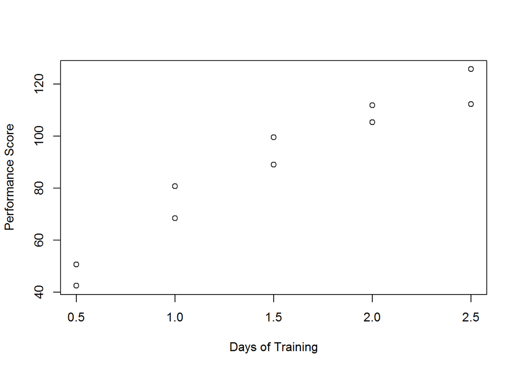

```r
plot(dat$x, dat$y, xlab = 'Days of Training', ylab = 'Performance Score')
```

Fit a simple linear model and add the regression line.

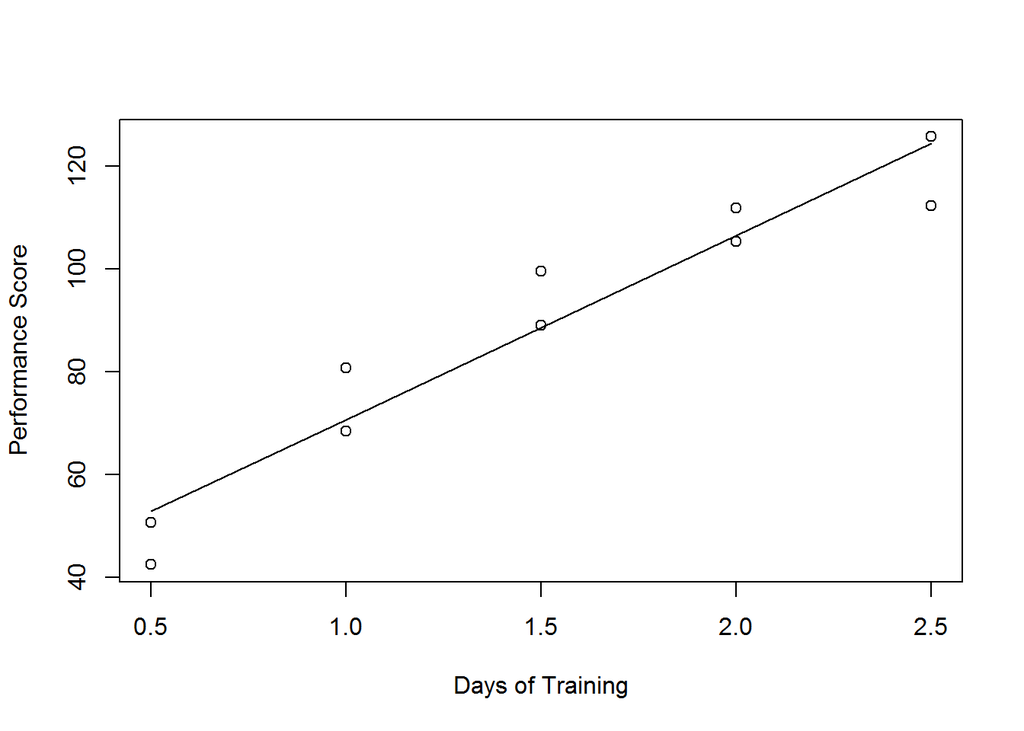

```r
fit = lm(y ~ x, data = dat)
plot(dat$x, dat$y, xlab = 'Days of Training', ylab = 'Performance Score')
points(dat$x, fit$fit, type = 'l')
```

To detect outliers and asymmetry,

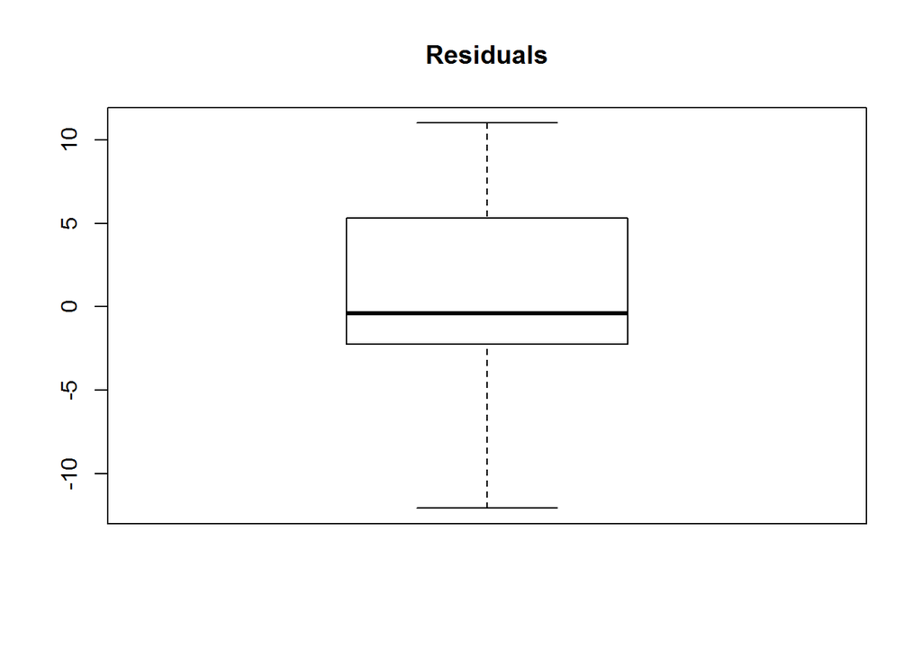

```r
boxplot(fit$res, main = 'Residuals')
```

To detect nonlinearity, heteroscedasticity, and outliers,

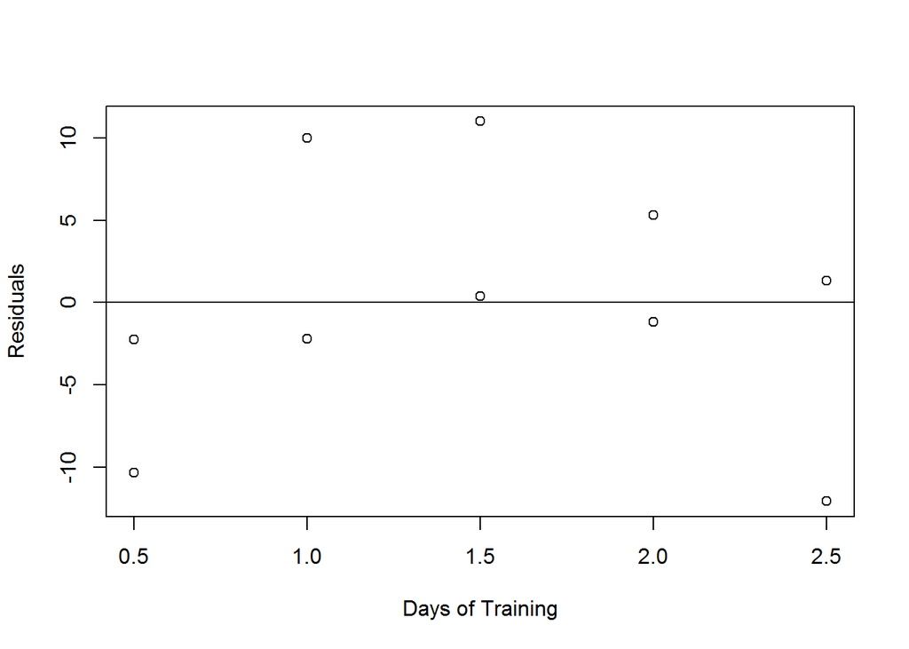

```r
plot(dat$x, fit$res, xlab = 'Days of Training', ylab = 'Residuals'); abline(h = 0)
```

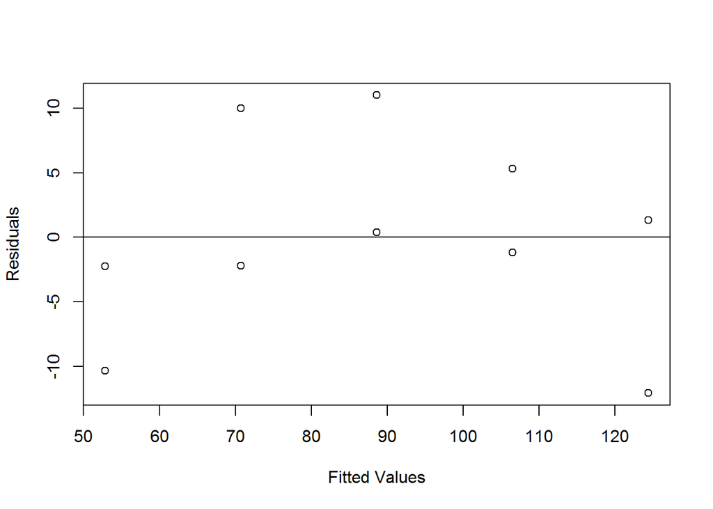

```r
plot(fit$fit, fit$res, xlab = 'Fitted Values', ylab = 'Residuals'); abline(h = 0)
```

In simple linear regression, the two plots above are redundant.

Up until now, we have used a new line every time we entered a new command. If you want more than one command on the same line, you can use a semicolon to separate them.

The `abline()` command adds a ’h’orizontal line at 0 to the last plot created.

Want: no systematic patterns, an even spread about 0.

To detect non-normality,

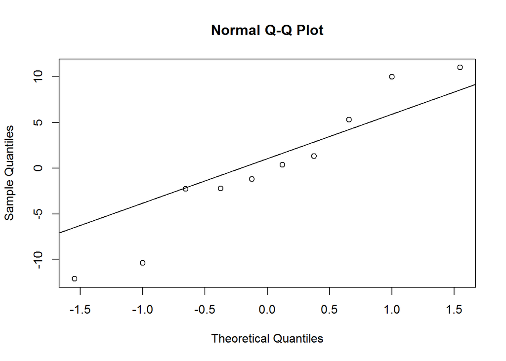

```r
qqnorm(fit$res); qqline(fit$res)
```

Want: points to fall on the theoretical line.

Are the above plots satisfactory? If not, what can we do?

### Transformation

Since the residuals vs predictor/fitted values plots exhibit a parabolic pattern with homoscedasticity, let’s try the transformation $X' = \sqrt{X}$.

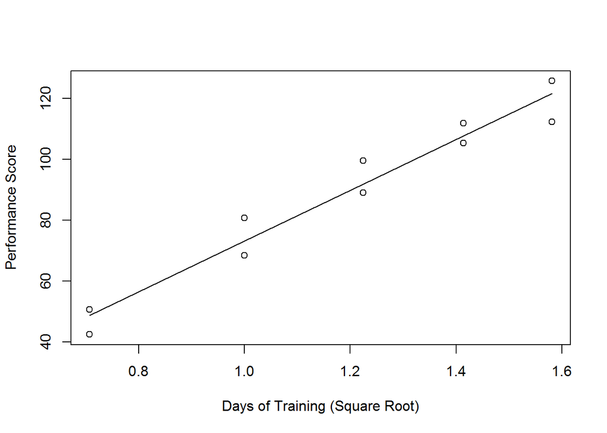

```r
x.trans = sqrt(dat$x)
fit = lm(dat$y ~ x.trans)
plot(x.trans, dat$y, xlab = 'Days of Training (Square Root)',
     ylab = 'Performance Score')
points(x.trans, fit$fit, type = 'l')
```

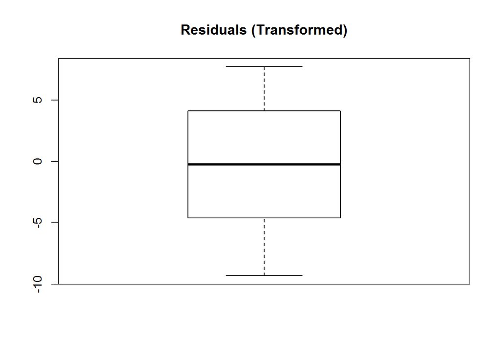

```r
boxplot(fit$res, main = 'Residuals (Transformed)')
```

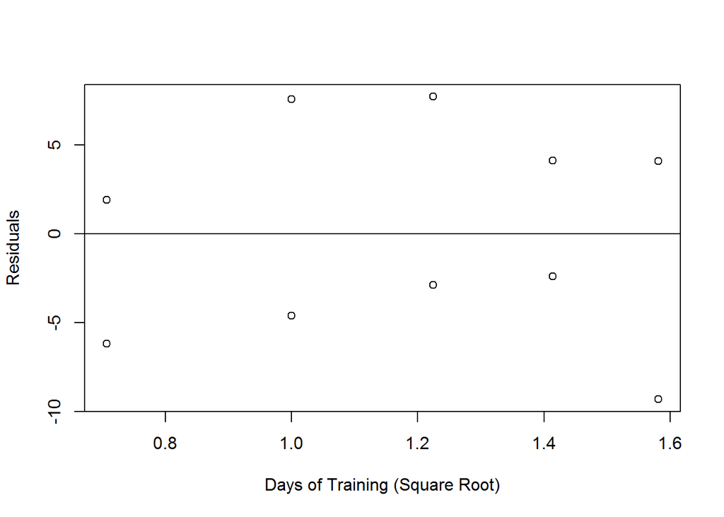

```r
plot(x.trans, fit$res, xlab = 'Days of Training (Square Root)',
     ylab = 'Residuals'); abline(h = 0)
```

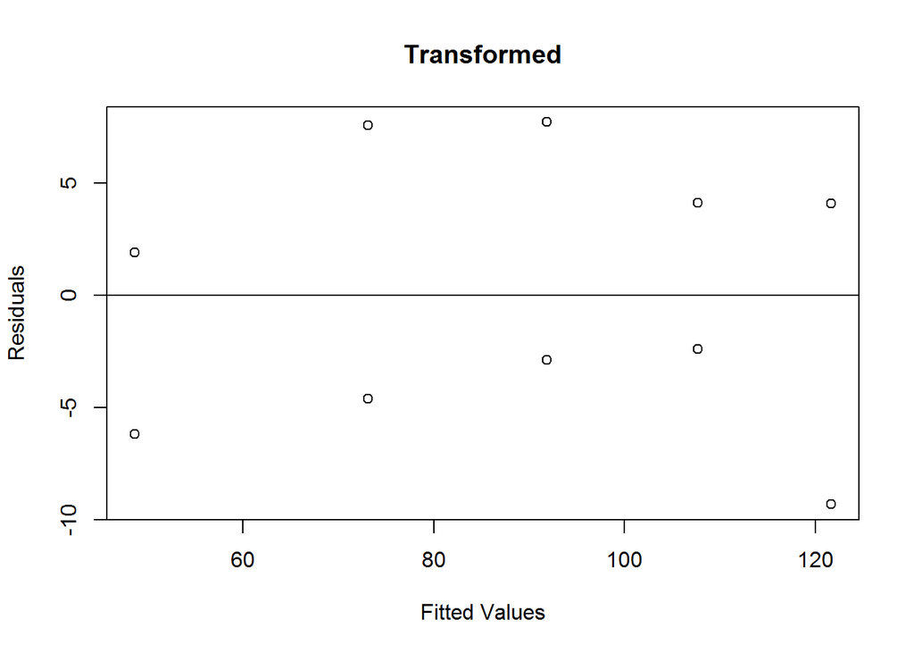

```r
plot(fit$fit, fit$res, xlab = 'Fitted Values', ylab = 'Residuals',
     main = 'Transformed'); abline(h = 0)
```

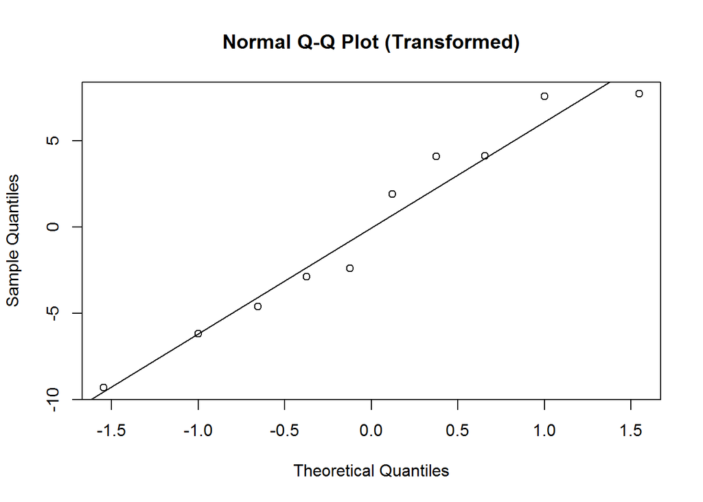

```r
qqnorm(fit$res, main = 'Normal Q-Q Plot (Transformed)'); qqline(fit$res)
```

What are your thoughts on these plots?